# Movie Industry Development Analysis

#### Team Member (Group 21): Yefei Fan, Bing Wu, Chengqi Wu

[figure not shown]

### Background

With the general improvement of living conditions, people begin to pursue the spiritual life. Thus, movie has become an essential entertainment in our life. In recent years, the global film industry has developed rapidly. The quantity and box office of popular films have frequently hit new records. Data analysis plays a vital role for providing decision support for movie production and investment. Data can provide rational expectations for the market and evaluate commercial implications in a qualitative and quantitative way. Thus, analyzing the development of movie industry is significantly meaningful.

Rotten Tomatoes and the Tomatometer score (critics score) are the world’s most trusted recommendation resources for quality entertainment. As the leading online aggregator of movie and TV show reviews from critics, Rotten Tomatoes provide fans with a comprehensive guide to what’s Fresh – and what’s Rotten – in theaters and at home. Thus, analyzing movies popularity on Rotten Tomatoes has a significant referential value for movie industry.

### Objective

We will analyze the development information of movie in the past 100 years. Our dataset includes movie basic information and its relavant rotten tomatoes scores information. Our goal is to provide valuable insights for movie producer newbies on how movie industry changed and developed through the past 100 years and what factors might affect movie's quality, helping new movie producers to be more successful on the start of their career.

### Data Context

The movie information comes from an extension of MovieLens10M database, published by GroupLeans research group as well as from website. It links the movies of MovieLens dataset with their corresponding web pages at Internet Movie Database (IMDb) and Rotten Tomatoes movie review systems. This dataset contains 7 files (movies.dat, movie_genres.dat, movie_directors.dat, movie_actors.dat, movie_countries.dat, tags.dat, movie_tags.dat), which contains rating and tags from 2113 users, 10197 movies from 20 genres, 4060 directors, 95321 actors and 72 countries.

In addition, in order to enrich our analysis martix, we introduce the outsource about mainsteam movies awards like Oscar, Goldener Bär, Leone d'oro and Golden Globe Awards from websites, we directly access it from html. These tables contain the basic information of these movies, like title, production company, year of relaase and the award they win. The resource website links are listed below:

- https://www.filmsite.org/bestpics3.html
- https://www.filmsite.org/bestpics4.html
- https://en.wikipedia.org/wiki/Golden_Lion#Golden_Lion_Honorary_Award
- https://en.wikipedia.org/wiki/Golden_Bear
- https://en.wikipedia.org/wiki/Palme_d%27Or

After data preprocessing, there are 16 variables in our data set:

- id: the unique identity of movie
- title: the title of movie
- year: the year that movie published
- rtAllCriticsNumReviews: the number of critics reviews for a movie
- rtAllCriticsScore: the critics score for a movie
- rtTopCriticsNumReviews: the number of top critics reviews for a movie
- rtTopCriticsScore: the top critics score for a movie
- rtAudienceNumRatings: the number of audience ratings for a movie
- rtAudienceScore: the audience score for a movie
- award: whether a movie is awarded or not (0 means unawarded, 1 means awarded)
- numOfActors: the number of actors for a movie
- country: the country that movie made
- numOfGenres: the number of genres for a movie
- genre: the genre(s) for a movie
- directorName: the director name of a movie
- numOfDirectorMovies: the number of movies directed by a director

### Analysis Roadmap:

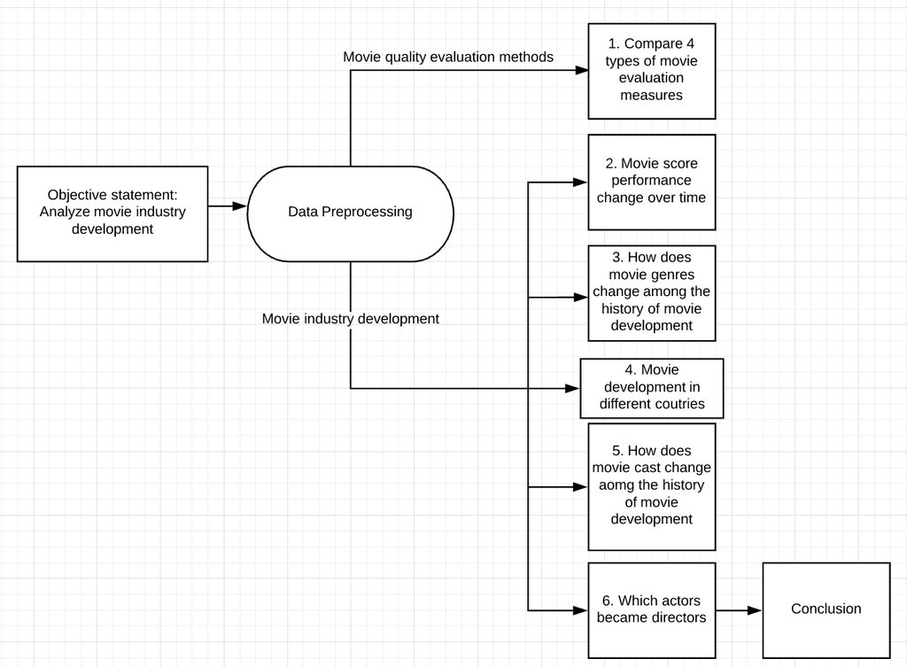

## Data Preprocessing

In this section we will take the first look at the loaded data frames. We will also perform necessary cleaning and some transformations so that the data better suits our needs.

- Importing data using pandas
- Data cleaning, handling missing values using fillna()
- Removing duplicates
- Filtering, sorting and ranking, deleting unuserful columns
- Merging data using merge()
- For loop to create new columns
- definate functions
- Using regular expression to extract information
- Using aggregation, groupby, pivot table

### Part 1: Import and clean data

```python
# Import modules and configure settings
import pandas as pd
import numpy as np
import matplotlib as mpl
import matplotlib.pyplot as plt
import seaborn as sns
import re
import csv
import sys
from sklearn.model_selection import train_test_split
from sklearn.linear_model import LinearRegression
from sklearn.tree import DecisionTreeRegressor

# Prevent warning message, making report more user-friendly
if not sys.warnoptions:
    import warnings
    warnings.simplefilter("ignore")
```

Import movies.csv data

```python
# Define file path and preview data
path ='/Users/iriswu/Desktop/课程/758X/project/data/'

# Read data to movies using pandas read_csv module
movies = pd.read_csv(path + 'movies.csv',sep = '\t',encoding='latin1')

# Preview the origianl data
movies.head(2)
```

|  | id | title | imdbID | spanishTitle | imdbPictureURL | year | rtID | rtAllCriticsRating | rtAllCriticsNumReviews | rtAllCriticsNumFresh | ... | rtAllCriticsScore | rtTopCriticsRating | rtTopCriticsNumReviews | rtTopCriticsNumFresh | rtTopCriticsNumRotten | rtTopCriticsScore | rtAudienceRating | rtAudienceNumRatings | rtAudienceScore | rtPictureURL |
| --- | --- | --- | --- | --- | --- | --- | --- | --- | --- | --- | --- | --- | --- | --- | --- | --- | --- | --- | --- | --- | --- |
| 0 | 1 | Toy story | 114709 | Toy story (juguetes) | http://ia.media-imdb.com/images/M/MV5BMTMwNDU0... | 1995 | toy_story | 9 | 73 | 73 | ... | 100 | 8.5 | 17 | 17 | 0 | 100 | 3.7 | 102338 | 81 | http://content7.flixster.com/movie/10/93/63/10... |
| 1 | 2 | Jumanji | 113497 | Jumanji | http://ia.media-imdb.com/images/M/MV5BMzM5NjE1... | 1995 | 1068044-jumanji | 5.6 | 28 | 13 | ... | 46 | 5.8 | 5 | 2 | 3 | 40 | 3.2 | 44587 | 61 | http://content8.flixster.com/movie/56/79/73/56... |

2 rows × 21 columns

```python
# Origianl data frame cleaning

# Drop duplicated rows
movies = movies.drop_duplicates('imdbID')

# Delete useless columns in movies dataframe
movies = movies.drop(['imdbID','spanishTitle','imdbPictureURL','rtID','rtPictureURL','rtAllCriticsRating','rtAllCriticsNumFresh','rtAllCriticsNumRotten','rtTopCriticsRating','rtTopCriticsNumFresh',
       'rtTopCriticsNumRotten','rtAudienceRating'], axis=1)

# Clean data format for columns "rtAllCriticsNumReviews",'rtAllCriticsScore','rtTopCriticsNumReviews','rtTopCriticsScore','rtAudienceNumRatings','rtAudienceScore'
a = ['rtAllCriticsNumReviews','rtAllCriticsScore','rtTopCriticsNumReviews','rtTopCriticsScore','rtAudienceNumRatings','rtAudienceScore']
for i in range(6):
    movies[a[i]] = movies[a[i]].str.replace('\\\\N', '0')

# Correct data type
# Change type of columns 'rtAllCriticsNumReviews','rtAllCriticsScore','rtTopCriticsNumReviews','rtTopCriticsScore','rtAudienceNumRatings','rtAudienceScore' to numeric
movies[['rtAllCriticsNumReviews','rtAllCriticsScore','rtTopCriticsNumReviews','rtTopCriticsScore','rtAudienceNumRatings','rtAudienceScore']] = movies[["rtAllCriticsNumReviews",'rtAllCriticsScore','rtTopCriticsNumReviews','rtTopCriticsScore','rtAudienceNumRatings','rtAudienceScore']].apply(pd.to_numeric)
# Change type of column 'id' to object
movies['id']=movies['id'].astype(object)
```

```python
movies.head(2)
```

|  | id | title | year | rtAllCriticsNumReviews | rtAllCriticsScore | rtTopCriticsNumReviews | rtTopCriticsScore | rtAudienceNumRatings | rtAudienceScore |
| --- | --- | --- | --- | --- | --- | --- | --- | --- | --- |
| 0 | 1 | Toy story | 1995 | 73 | 100 | 17 | 100 | 102338 | 81 |
| 1 | 2 | Jumanji | 1995 | 28 | 46 | 5 | 40 | 44587 | 61 |

Based on domain knowledge, whether a movie has won award or not is also an important factor for our analysis. Therefore, we decided to scripting the most famous film festival award information from internet and find the awarded movies. We choose four film festivals: Oscar Film Festival, Berlin Internation FIlm Festival, Cannes International Film Festival and Venice International Film Festival. These four festivals have the most significant impact on movie industry development.

Even though the process is very similar to the data scriping process above, but the cleaning detail is quite different for tables from the different resource.

One example of raw data is here: (from 'https://www.filmsite.org')

[figure not shown]

```python
# Read HTML table using url address
url1 = 'https://www.filmsite.org/bestpics3.html'
df = pd.read_html(url1,index_col=None,header=None,skiprows=2)

# Transform data into pandas dataframe for later manipulation
oscar_best_movies_1 = df[0]

# Scripted data cleaning

# Delete useless columns
del oscar_best_movies_1[3]
del oscar_best_movies_1[4]
del oscar_best_movies_1[5]

# Change column names
col_name = ['Year','Best Academy Award Movie','Film Director']
oscar_best_movies_1.columns = col_name

# Clean column 'Year'
oscar_best_movies_1['Year'] = oscar_best_movies_1['Year'].str.replace('-\d*','')

# Clean column 'Best Academy Award Movie'
oscar_best_movies_1['Best Academy Award Movie'] = oscar_best_movies_1['Best Academy Award Movie'].str.replace('\(\w+\s*\w*\)\s*\w*','')
oscar_best_movies_1['Best Academy Award Movie'] = oscar_best_movies_1['Best Academy Award Movie'].str.replace('\(\w+\s*\w*\s*\w*\s*\w*\)','')

# Clean column 'Film Director'
oscar_best_movies_1['Film Director'] = oscar_best_movies_1['Film Director'].str.replace('\*','')
oscar_best_movies_1['Film Director'] = oscar_best_movies_1['Film Director'].str.replace('\(\D*\)','')

# Remove missing value
oscar_best_movies_1 = oscar_best_movies_1.dropna()
oscar_best_movies_1.head(2)
```

|  | Year | Best Academy Award Movie | Film Director |
| --- | --- | --- | --- |
| 0 | 1927 | Wings | William A. Wellman |
| 1 | 1928 | The Broadway Melody | Harry Beaumont |

##### The following four awards data frames look similar like this one. Therefore, we won't spare more space to show the following data frames .

Import 1960s - 2008 Academy Award for Best Picture (Oscar Film Festival) data.

```python
# Read HTML table using url address
url2 = 'https://www.filmsite.org/bestpics4.html'
df = pd.read_html(url2,index_col=None,header=None,skiprows=2)

# Transform into data frame
oscar_best_movies_2 = df[0]

# Delete useless columns
del oscar_best_movies_2[3]
del oscar_best_movies_2[4]
del oscar_best_movies_2[5]

# Change column names
col_name = ['Year','Best Academy Award Movie','Film Director']
oscar_best_movies_2.columns = col_name

# Clean column ['Film Director']
oscar_best_movies_2['Film Director'] = oscar_best_movies_2['Film Director'].str.replace('\*','')
oscar_best_movies_2['Film Director'] = oscar_best_movies_2['Film Director'].str.replace('and\s\w*\s\w*','')

# Concatenate two oscar dataframes
oscar_best_movies = pd.concat([oscar_best_movies_1, oscar_best_movies_2], ignore_index=True)

# Merge oscar_best_movies with movies dataframe for later usage
oscar_movies = pd.merge(oscar_best_movies, movies, left_on='Best Academy Award Movie', right_on='title')

# Delete wrong data
oscar_movies = oscar_movies.drop(oscar_movies.index[[14,15,19,69]])

# Delete useless columns
oscar_movies = oscar_movies.drop(columns=['title','Year'])

# Drop missing values
oscar_movies = oscar_movies.dropna()
```

Import list of 1920s - 2008 Golden Lion Award (Venice Movie Festival) data

```python
# Read HTML table using url address
url3 = 'https://en.wikipedia.org/wiki/Golden_Lion#Golden_Lion_Honorary_Award'
df = pd.read_html(url3,index_col=None,header=None,skiprows=3)

# Transform into dataframe
venice_best_movies = df[1]

# Delete useless columns
del venice_best_movies[4]
del venice_best_movies[3]
del venice_best_movies[2]

# Change columns name
col_name = ['Year','Golden Lion Award Movie']
venice_best_movies.columns = col_name

# Clean columns ['Year']
venice_best_movies = venice_best_movies.drop(venice_best_movies.index[venice_best_movies[venice_best_movies['Year'].str.contains('t')].index])
venice_best_movies = venice_best_movies.dropna()

# Clean columns ['Golden Lion Award Movie']
index_list = list(venice_best_movies[venice_best_movies['Golden Lion Award Movie'].str.contains('No award')].index)
venice_best_movies = venice_best_movies.drop(index_list)

index_list_1 = list(venice_best_movies[venice_best_movies['Golden Lion Award Movie'].str.contains('\(tie')].index)
venice_best_movies = venice_best_movies.drop(index_list_1)

# Split rows to Year 2011
venice_best_movies = venice_best_movies.loc[:67,:]

# Merge venice_best_movies with movies dataframe
venice_movies = pd.merge(venice_best_movies, movies, left_on='Golden Lion Award Movie', right_on='title')

# Delete wrong data
venice_movies = venice_movies.drop(venice_movies.index[[0]])

# Delete useless columns
venice_movies = venice_movies.drop(columns=['title','Year'])
```

Import list of 1920s - 2008 Golden Bear Award (Berlin Film Festival) data

```python
# Reading award data using URL
url4 = 'https://en.wikipedia.org/wiki/Golden_Bear'
berlin_best_movies = pd.read_html(url4,index_col=None,header=None,skiprows=3)[1]

# Delete useless columns
del berlin_best_movies[4]
del berlin_best_movies[3]
del berlin_best_movies[2]

# Change columns name
col_name = ['Year','Golden Bear Award Movie']
berlin_best_movies.columns = col_name

# Split rows to 2011
berlin_best_movies =  berlin_best_movies.loc[:81,:]

# Clean columns ['Year']
berlin_best_movies = berlin_best_movies.drop(berlin_best_movies.index[list(berlin_best_movies[berlin_best_movies['Year'].str.contains('\d{4}s')].index)])
berlin_best_movies = berlin_best_movies.drop(berlin_best_movies.index[list(berlin_best_movies[berlin_best_movies['Year'].str.contains('\d{4}\-')].index)])

# Set new index
new_index = pd.Series(list(range(len(berlin_best_movies))))
berlin_best_movies.set_index(new_index)

# Correct disordered data
for i in range(len(berlin_best_movies)):
    if berlin_best_movies.iloc[i,0].isdigit() == False:
        berlin_best_movies.iloc[i,1] = berlin_best_movies.iloc[i,0]
        berlin_best_movies.iloc[i,0] = berlin_best_movies.iloc[i-1,0]
        i += 1

# Clean columns ['Golden Bear Award Movie']
berlin_best_movies['Golden Bear Award Movie'] = berlin_best_movies['Golden Bear Award Movie'].str.replace('\(\w*\s*\w*\s*\w*\s*\&*\s*\w*\)','')

# Merge berlin_best_movies with movies dataframe
berlin_movies = pd.merge(berlin_best_movies, movies, left_on='Golden Bear Award Movie', right_on='title')

# Delete useless columns
berlin_movies = berlin_movies.drop(columns=['title','Year'])

# Delete wrong data
berlin_movies = berlin_movies.drop(berlin_movies.index[[1]])
```

Import list of 1920s - 2011 Palme dOr Award (Cannes Film Festival) data

```python
# Reading award data using URL
url5 = 'https://en.wikipedia.org/wiki/Palme_d%27Or'
cannes_best_movies = pd.read_html(url5,index_col=None,header=None,skiprows=3)[1]

# Delete useless columns
del cannes_best_movies[4]
del cannes_best_movies[3]
del cannes_best_movies[2]

# Change columns name
col_name = ['Year','Palme dOr Award Movie']
cannes_best_movies.columns = col_name

# Split rows to Year 2011
cannes_best_movies =  cannes_best_movies.loc[:96,:]

# Clean columns ['Year']
cannes_best_movies = cannes_best_movies.drop(cannes_best_movies.index[list(cannes_best_movies[cannes_best_movies['Year'].str.contains('–')].index)])
cannes_best_movies = cannes_best_movies.drop(cannes_best_movies.index[list(cannes_best_movies[cannes_best_movies['Year'].str.contains('\d{4}s')].index)])

cannes_best_movies['Year'] = cannes_best_movies['Year'].str.replace('1939\s\W','1939')

# Drop missing data
cannes_best_movies = cannes_best_movies.dropna()

# Correct the data
for i in range(len(cannes_best_movies)):
    if cannes_best_movies.iloc[i,0].isdigit() == False:
        cannes_best_movies.iloc[i,1] = cannes_best_movies.iloc[i,0]
        cannes_best_movies.iloc[i,0] = cannes_best_movies.iloc[i-1,0]
        i += 1

# Clean columns ['Palme dOr Award Movie']
cannes_best_movies['Palme dOr Award Movie'] = cannes_best_movies['Palme dOr Award Movie'].str.replace('\s\§','')

# Merge cannes_best_movies with movies dataframe
cannes_movies = pd.merge(cannes_best_movies, movies, left_on='Palme dOr Award Movie', right_on='title')

# Delete useless columns
cannes_movies = cannes_movies.drop(columns=['title','Year'])

# Delete wrong data
cannes_movies = cannes_movies.drop(cannes_movies.index[[0]])
```

### Part 2: Create variables and modify data frame

We then create seven new variables for data frame for further analysis part:

- award: whether a movie is awarded or not (0 means unawarded, 1 means awarded)
- numOfActors: the number of actors for a movie
- country: the country that movie made
- numOfGenres: the number of genres for a movie
- genre: the genre(s) for a movie
- directorName: the director name of a movie
- numOfDirectorMovies: the number of movies directed by a director

After scripting film award inforamtion from website, we want to create a new column 'award' in new_movies data frame: Award=1 if that movie obtain any award, otherwise 0.

```python
# Create two Series df1 and df2
df1 = pd.Series(movies['id'],index=range(len(movies['id'])))
df2 = pd.Series(np.zeros(len(movies['id'])),index=range(len(movies['id'])))

# Concatenate two Series
movies_sub = pd.concat([df1, df2], axis=1)
movies_sub = pd.DataFrame(movies_sub)

# Create an id list that contains all ids of awarded movies
idlist = []
idlist.extend(oscar_movies['id'])
idlist.extend(cannes_movies['id'])
idlist.extend(venice_movies['id'])
idlist.extend(berlin_movies['id'])

# Function to get unique values from a list
def unique(list1):
    # intilize a null list
    unique_list = []
    # traverse for all elements
    for x in list1:
        # check if exists in unique_list or not
        if x not in unique_list:
            unique_list.append(x)
    return unique_list

unique_idlist = unique(idlist)

# Assign 1 to column [0] if that movie won award
for i in range(len(movies['id'])):
    if movies_sub['id'][i] in unique_idlist:
        movies_sub.iloc[i,1] = 1


# Merge two data frames
new_movies = pd.merge(movies, movies_sub, left_on='id', right_on='id')

# Change column name [0] to ['award']
new_movies=new_movies.rename(columns = {0:'award'})
```

We think the number of actors might be a important factor for analysis. Thus, we create a new column 'numOfActors' in new_movies data frame: counting the number of actors in each movie. The data is from the same directory with movies.csv data.

```python
# Import movie_actors.csv
actors = pd.read_csv(path + 'movie_actors.csv',sep = '\t',encoding='latin1')

# Count the number of actors for each movieId
num_of_actors = actors.groupby(by='movieID',sort = False).size()
num_of_actors = pd.DataFrame(num_of_actors)
num_of_actors

# Create two Series df1 and df2
df3 = pd.Series(movies['id'],index=range(len(movies['id'])))
df4 = pd.Series(np.zeros(len(movies['id'])),index=range(len(movies['id'])))

# Concatenate two Series
movies_sub_2 = pd.concat([df3, df4], axis=1)
movies_sub_2 = pd.DataFrame(movies_sub_2)

# Assign number of actor to column [0]
for i in range(len(new_movies)):
    if num_of_actors.index[i] in new_movies['id']:
        movies_sub_2.iloc[i,1] = num_of_actors.iloc[i,0]
        i += 1

movies_sub_2

# Merge two data frames
new_movies = pd.merge(new_movies, movies_sub_2, left_on='id', right_on='id')

# Change column name [0] to 'numbOfActors'
new_movies=new_movies.rename(columns = {0:'numOfActors'})
```

We find that the information from movie_countries might also be helpful for analysis. Therefore, we create a new column 'country' in new_movies data frame. The data is from the same directory with movies.csv data.

```python
# Import movie_countries.csv
countries = pd.read_csv(path + 'movie_countries.csv',sep = '\t',encoding='latin1')

# Change column 'movieID' type
countries['movieID']=countries['movieID'].astype(object)

# Merge new_movies and countries data frame
new_movies = pd.merge(new_movies, countries, left_on='id', right_on='movieID')
new_movies

# Delete column 'movieID' because it is the same with column 'id'
del new_movies['movieID']
```

We think genres is also an important information for our analysis. So we created new columns 'genres' and 'numOfGenres' for our dataset. We use genres to illustrate what are the genres a movie have and numOfGenres to show the number of genres a movie includes. The data is from the same directory with movies.csv data.

```python
# Load genres of movie
genres = pd.read_table(path + 'movie_genres.csv',encoding ='ISO-8859-1',header = 0, index_col=0 )

# Change column 'movieID' type
new_movies['id']=new_movies['id'].astype(int)

# Calculate the number of genre of each movies
gnum = genres.groupby(by = 'movieID').count()
new_movies=new_movies.merge(gnum,left_on='id',right_on='movieID',left_index=False)
# Change the new of column genre to numberOfGenres
new_movies=new_movies.rename(columns = {'genre':'numOfGenres'})

# Group genre to to every movieID using '|' as seperator and change column name
genres = genres.groupby('movieID')['genre'].apply('|'.join).reset_index()
genres = genres.rename(index=str, columns={"movieID": "id"})

# Merge genres to new_movies
new_movies = pd.merge(new_movies, genres, on='id')

# change column 'movieID' type
new_movies['id']=new_movies['id'].astype(object)
```

We also want to include the information of director so we count the number of movie directored by each director to create a new column called 'numOfDirectorMovies' and a new column called 'director' for our dataset. The data is from the same directory with movies.csv data.

```python
# Import movie_directors.csv
directors = pd.read_table(path + 'movie_directors.csv', encoding ='ISO-8859-1',header = 0, index_col=1 )

# Count the number of movies directed by each director
num_movie=directors['movieID'].groupby(by='directorID').count()

#Calculate the number of movie each director have
directors['numOfDirectorMovies']=num_movie

# Change column 'movieID' type
new_movies['id']=new_movies['id'].astype(int)

# Merge director into new_movies
new_movies = new_movies.merge(directors, left_on='id',right_on='movieID')

# Change column 'movieID' type
new_movies['id']=new_movies['id'].astype(object)

# Delete column 'movieID' because it is the same with column 'id'
del new_movies['movieID']
```

Now we have a relatively completed dataset which contains information for our further analysis. We set 'id' as index and then print the first 3 rows in our new_movies data to preview the dataframe.

```python
# Set 'id' as index
new_movies = new_movies.set_index('id')
# Print first 5 rows in new_movies
new_movies.head(3)
```

| id | title | year | rtAllCriticsNumReviews | rtAllCriticsScore | rtTopCriticsNumReviews | rtTopCriticsScore | rtAudienceNumRatings | rtAudienceScore | award | numOfActors | country | numOfGenres | genre | directorName | numOfDirectorMovies |
| --- | --- | --- | --- | --- | --- | --- | --- | --- | --- | --- | --- | --- | --- | --- | --- |
| 1 | Toy story | 1995 | 73 | 100 | 17 | 100 | 102338 | 81 | 0.0 | 24.0 | USA | 5 | Adventure\|Animation\|Children\|Comedy\|Fantasy | John Lasseter | 5 |
| 2 | Jumanji | 1995 | 28 | 46 | 5 | 40 | 44587 | 61 | 0.0 | 18.0 | USA | 3 | Adventure\|Children\|Fantasy | Joe Johnston | 6 |
| 3 | Grumpy Old Men | 1993 | 36 | 66 | 6 | 83 | 10489 | 66 | 0.0 | 16.0 | USA | 2 | Comedy\|Romance | Donald Petrie | 12 |

### Part 3: Show basic information of data frame

```python
new_movies.info()
```

```
<class 'pandas.core.frame.DataFrame'>
Int64Index: 8731 entries, 1 to 51304
Data columns (total 15 columns):
title                     8731 non-null object
year                      8731 non-null int64
rtAllCriticsNumReviews    8731 non-null int64
rtAllCriticsScore         8731 non-null int64
rtTopCriticsNumReviews    8731 non-null int64
rtTopCriticsScore         8731 non-null int64
rtAudienceNumRatings      8731 non-null int64
rtAudienceScore           8731 non-null int64
award                     8731 non-null float64
numOfActors               8731 non-null float64
country                   8725 non-null object
numOfGenres               8731 non-null int64
genre                     8731 non-null object
directorName              8731 non-null object
numOfDirectorMovies       8731 non-null int64
dtypes: float64(2), int64(9), object(4)
memory usage: 1.1+ MB
```

## Data Analysis and Data Visualization

### 1. Analyze Movie Evaluation Methods

Usually, Rotten Tomatoes and the Tomatometer score are the world’s most trusted recommendation resources for quality entertainment. Also, best movie awards of famous film festivals are another trusted resources to measure a movie's quality. Thus, in the first part, we will analyze audience score, critics score and top critics score on Rotten Tomatoes, as well as movie award status.

#### Distribution of Scores on Rotten Tomatoes

Let's first look at the distribution of the three types of scores on Rotten Tomatoes, the general audience, the professional critics and the top critics respectively. We expect to see some variance on each category because high variance means that there are difference exisiting in each variable. Thus, varaibles are significant to analyze in the following steps. We use three subplots to visualize it. The x-axis represents the scores and the y-axis represents the percentage. We also add a line to visualize the distribution trend.

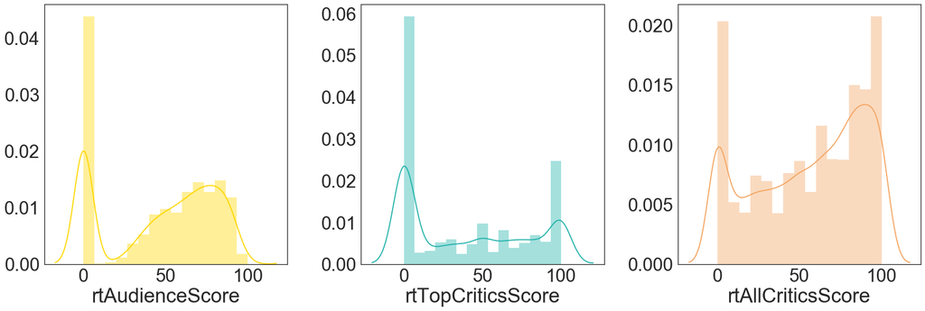

```python
# Set the style, axes and figure of our plot
sns.set_style('white')
fig, axes = plt.subplots(1, 3)
# Set figure size
fig.set_size_inches(22, 8)
# Set font size
sns.set(font_scale=3)

# Plot distribution of 'rtAudienceScore', 'rtTopCriticsScore', 'rtAllCriticsScore' using histgram
m1 = sns.distplot(new_movies.rtAudienceScore,15,ax=axes[0],color='gold')
m2 = sns.distplot(new_movies.rtTopCriticsScore,15,ax=axes[1],color='lightseagreen')
m3 = sns.distplot(new_movies.rtAllCriticsScore,15,ax=axes[2],color='sandybrown')

plt.tight_layout()
```

#### Findings:

We have several findings. All three types of scores have relatively high variances and there is discrepency among three types of scores. The proportion of full-score film from critics is significantly higher than that of general audience. If ignoring 0-score movies, the audience score is more closer to normal distributed, while the critics scores and top critics scores are more skewed distributed.

After researching the reason behind the plot, we find that the critics need to ask themself two questions when they are rating a movie: (1)Is this movie worth my money and (2) does this movie expand or devalue my information about human nature. However, to normal movie reviewers they focus more or only on question 1 and are largely concerned with short term. Therefore, there are many movies that are welcomed by critics but did not perform well in general movie viewers.[1]

For example, 'The Shawshank Redemption' was released in 1994. The general movie viewers didn't like this movie and it performed badly in movie industry. However, critics gave 'The shawshank Redemption' a positive comment and think this is a valuable movie. Consequently, 'The shawshank Redemption' became time-tested, extremely successful movie, ranking in NO.1 of the best movie in history in IMDb.

Also, we can see from the plot that critics have similiar standard to rating a mvoie because there are large amount of movie are full-socres by critics.We learned that critics opinions do tend to cluster on most film because of the similar background they have and those critics scores are more controled and methodical.[2]

In addition, we notice that there are a lot of 0-score movies in dataset. After analysis, it has two reasons: one is that there is no people rate it and another is all people give 0s to that movie. After discussion, we think 0-score movies themselves are meaningful and decide to keep it in our dataset.

#### Quantitive Analysis of Difference of Scores on Rotten Tomatoes

We then want to see the statistic difference among audience score, top critics score and critics score, in terms of mean, median, variance and so on. These statistical information could give us more comparisons among three types of ratings, helping us interpret audience score (which stands for movie quality among general viewers) better. We use a horizontal boxplot for sake of comparison. The x-axis represents score and the y-axis represents three types of scores. The red line represents the medion score and the triangle represents the mean.

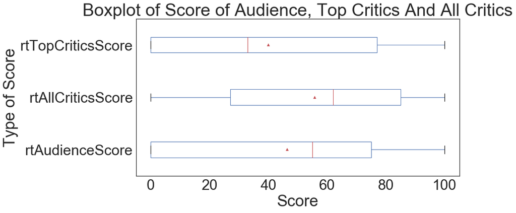

```python
# Visualize the statistical value comparasion of 'rtAudienceScore',
#'rtAllCriticsScore','rtTopCriticsScore'

# Set style and figure size
sns.set_style('white')
plt.figure(figsize = (12, 6))
# Plot boxplot for three score
new_movies.boxplot(column=['rtAudienceScore','rtAllCriticsScore',
                           'rtTopCriticsScore'],showmeans=True,
                   flierprops={'marker': '*'}, vert=False, grid=False)
# Set label of x axes and yaxes
plt.xlabel('Score')
plt.ylabel('Type of Score')
plt.title('Boxplot of Score of Audience, Top Critics And All Critics');
```

#### Findings:

From the figure, it can be seen that the mean and median of three types of scores are quite different. The median of all critics score is the highest: about 63; the median of top critics score is the lowest: about 30. The mean of all critics score is the highest: about 58; the mean of top critics score is the lowest: about 40.

Top critics have the lowest average scores. This makes sense. Based on our analysis above, it's very hard for a movie a get a high score from critics because they would not only consider the feeling when they watch the movie, they also take the long term influence of the movie into consideration.

#### Relationship of Award and Scores

As we have found the difference among three types of scores, we can see the standard of audience rating are pretty different from that of critics rating. Next, we will explore the relationship of award and three types of scores. We use a pivot table to demonstarte our analysis. We collect the mean, max scores for three different types as well as the number of awarded movies and unawarded movies.

```python
# Group the new_movies data by award, show number mean and max of three scores
award_table = pd.DataFrame(new_movies.groupby(by='award').agg({'rtAudienceScore':['count','mean','max'],'rtAllCriticsScore':['mean','max'],'rtTopCriticsScore':['mean','max']}))

# Sort valye by audience score and then count
award_table.sort_values(by=[('rtAudienceScore','count')], ascending = False)
```

| award | rtAudienceScore count | rtAudienceScore mean | rtAudienceScore max | rtAllCriticsScore mean | rtAllCriticsScore max | rtTopCriticsScore mean | rtTopCriticsScore max |
| --- | --- | --- | --- | --- | --- | --- | --- |
| 0.0 | 8623 | 45.983532 | 100 | 55.466891 | 100 | 39.569175 | 100 |
| 1.0 | 108 | 80.537037 | 97 | 84.259259 | 100 | 80.398148 | 100 |

The number of awarded movies is very small, only 108, and the number of unawarded movies is large, 8623. Three types of Rotten Tomatoes scores are much higher in awarded movies than in unawarded movies. The average scores of awarded movies are almost twice than the average scores of unawarded movies. Awarded movies all critics score and critics score are corresponding with the fact that those movie are awarded, which means that those movies are welcomed in critics. However, the highest audience score of unawarded movie is higher(100) than the highest audience score(97) of awarded movie. Additionally, one intersting thing is: the highest audience score is only 97 for awarded movie but is 100 for unaward movies. It indicates that the awarded movies might not be the audience most favorite movies.

In addition, we plot the distribution of audience score in awarded movies and unawarded movies to see the whole picture of the difference of the awarded and unawarded movies' scores. The x-axis represents audience score and y-axis represents density. The left plot is for awarded movies and the right plot is for unawarded movies.

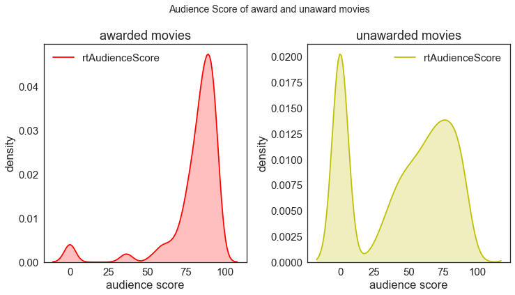

```python
# Subplot distribution of audience score of awarded movies
# and unawarded movies
sns.set_style('white')
fig = plt.figure(figsize = (12, 6))
title = fig.suptitle("Audience Score of award and unaward movies", fontsize=14)
fig.subplots_adjust(top=0.85, wspace=0.3)

# Subplot for awarded movies
ax1 = fig.add_subplot(1,2, 1)
ax1.set_title("awarded movies")
ax1.set_xlabel("audience score")
ax1.set_ylabel("density")
sns.kdeplot(new_movies[new_movies['award']==1]['rtAudienceScore'], ax=ax1, shade=True, color='r')

# Subplot for unawarded movies
ax2 = fig.add_subplot(1,2, 2)
ax2.set_title("unawarded movies")
ax2.set_xlabel("audience score")
ax2.set_ylabel("density")
sns.kdeplot(new_movies[new_movies['award']==0]['rtAudienceScore'], ax=ax2, shade=True, color='y')
plt.show()
```

### Analyze Development of Movie Industry

We have known the differences and relationships of four evaluation methods, we then choose audience score on Rotten Tomatoes as a main reference factor to analyze the development of movie industry. It is because as audience, we are more interested in how audience regards movies.

### 2. The Change of Movie Audience Score over Time

#### Change of audience score of movies in each 20-year period.

We first want to see the changing trend of audience score on different year's movies. We think it may give us some insights on how audience regard movies in different years. We use lmplot to visualize the trend of audience score in different year periods. We bin time by 20 years, from 1910 to 2010. The x-axis is year and the y-axis is audience score. Different colors represent movies in different time periods.

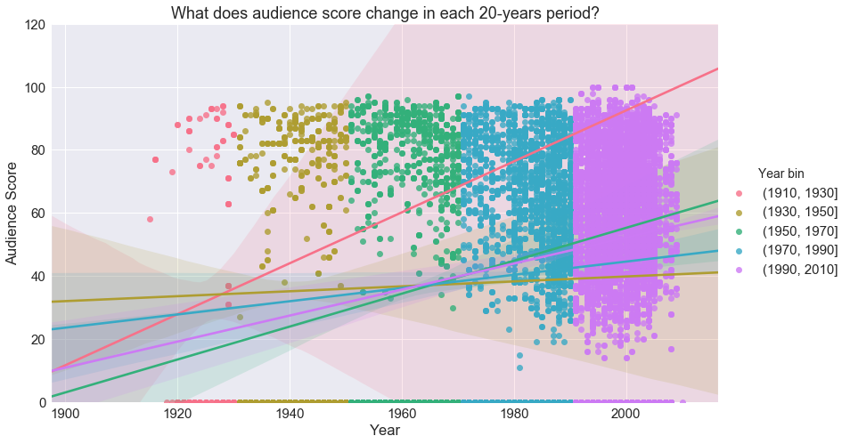

```python
# Set bins
bins=[1910,1930,1950,1970,1990,2010]
y = genres.join(movies[['year','rtAudienceScore']])
y['Year bin'] = pd.cut(y['year'],bins)
y.head()

# lmplot
sns.set_style('white')
sns.set(font_scale = 1.5)
plt.figure(figsize=(16,10))
g=sns.lmplot(x='year', y='rtAudienceScore',data=y, hue='Year bin', palette = "husl",aspect=20/12, size = 7)
g.set(ylim=(0,120))
plt.xlabel('Year')
plt.ylabel('Audience Score')
plt.title('What does audience score change in each 20-years period?')
plt.show()
```

###### In the plot above, each colored line represents a linear regression line for each time period respectively. Each shaded area is a pointwise 95% confidence interval on the fitted values (the line).

#### Findings:

From the plot, it can be seen that there are obvious difference among movie audience scores in different time periods. If ignoring the 0-score movies, the movies filmed at the beginning of movie history (1910s - 1930s) has the smallest range of audience scores, and most of the audience scores aggragate above 60. The ranges of audience scores enlarge as time goes on. There are more mixed reviews on more recent movies.

#### Average audience score of movies in each decade

Then, we want to see the average change of movies filmed in different years to get some insights on audience score. We make a line chart to visualize the mean audience score. The x-axis is timeline (year) and y-axis is audience score. We aggreagte each 10-year's average scores for analysis.

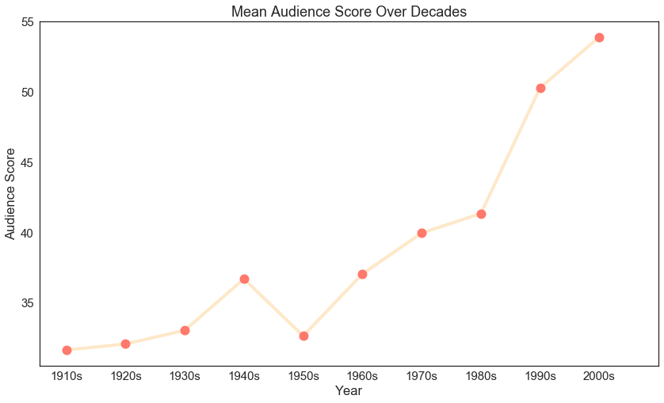

```python
# Set bins
bins=[1910,1920,1930,1940,1950,1960,1970,1980,1990,2000,2010]
h = genres.join(movies[['year','rtAudienceScore']])
h['cut'] = pd.cut(h['year'],bins)
sns.set_style('white')
a=h[['cut','rtAudienceScore']].groupby('cut').mean()

# Plot
f, ax= plt.subplots(figsize = (14, 8))
a.plot(grid=False,marker='o',color='#fee8c8',markersize=12,linewidth=4,legend=False,markerfacecolor='#ff796c',ax=ax)
plt.xticks(range(0,11),['1910s','1920s','1930s','1940s','1950s','1960s','1970s','1980s','1990s','2000s']);
plt.ylim=(0,100);
plt.xlabel('Year')
plt.ylabel('Audience Score')
plt.title('Mean Audience Score Over Decades');
```

#### Findings:

According to the article "How TV Killed Hollywood's Golden Age", we find that "during the 1940s and 1950s, movie palaces shuttered, once mighty studios closed down and some of Hollywood’s greatest actors, directors and screenwriters stopped making films. It was the end of an era and television was to blame: the new technology effectively killed Hollywood’s Golden Age. These days, you’re much more likely to turn on your television than to head to a movie theater. Here’s how TV captivated American audiences—and upended just about everything about the movie business along the way."[3]

### 3. The Movie Development of Different Genres

Genre is regarded as one of the most important elements of a movie. When we walk into the cinema aimlessly and want to choose one of the various films to kill time, we usually consider first whether it is an action film or a musical film, whether it is a science fiction masterpiece or a war drama. Thus, analyzing movie genres is necessary when analyzing movie popularity.

#### Origins of different movie genres

Diversity of genres are an important topic in the development of movies. From the perspective of the development of movie genres, we would like to explore the origins of each movie. We use scatter plot to visuliaze when a genre occured. The x-axis represents year and the y-axis represents different genres. If one particular genre movie was producted in one year, a dot will be displayed on the plot.

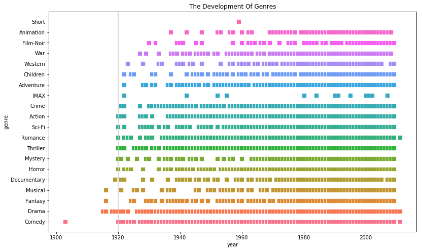

```python
# Read genres dataset for further analysis
genres = pd.read_table(path + 'movie_genres.csv',encoding ='ISO-8859-1',header = 0, index_col=0 )

# Join year and audience score into genres table
h = genres.join(movies[['year','rtAudienceScore']])

# Create bins using 10 years
bins=[1910,1920,1930,1940,1950,1960,1970,1980,1990,2000,2010]
h['cut'] = pd.cut(h['year'],bins)

# Group by genre and year to create table contain the apperance of each genre in each year
b=h[['genre','year']].groupby(['genre','year']).count().reset_index().sort_values(by='year')

# Set figure size
plt.figure(figsize=(13,8))

# Plot the scatter plot
sns.scatterplot(x='year', y='genre', data=b, marker='s', hue = 'genre',legend=False, s = 80);

# Set vertical timeline
plt.axvline(1920, color='0.8');

# Set title of this plot
plt.title('The Development Of Genres');
```

#### Findings:

The dominance of drama as a genre is perhaps not surprising when we consider the following:

- Drama is the cheapest genre to produce as movies don’t necessarily require special sets, costumes, locations, props, special/visual effects, etc.
- Drama has the broadest definition of all genres – everything that happens anywhere ever is a drama. Conversely, other genres have a higher bar for classification, such as the need for high-octane events for a movie to be classed as Action, scary events to be Horror, funny elements to be a Comedy, etc.[4]

Movie producers often complain that "drama is not a genre" because it does not provide any potential audience with clues about expectations. Instead, simply state that a movie is a Western film that conveys a wealth of information about what might be offered, including time periods, locations, tones, plot elements, characters, and so on.

#### Changes of number of movies in different genres

Besides the origin of movie genres, we then want to know the trend of each genre through time period. We take a closer look at the cumulative output of the different types of movies. Which genres flourished and which genres recessed? We utilize accumulative plot to visuliaze analysis. The x-axis stands for year and the y-axis represents cumulative number of movies in genres. Each color represents one specific genre.

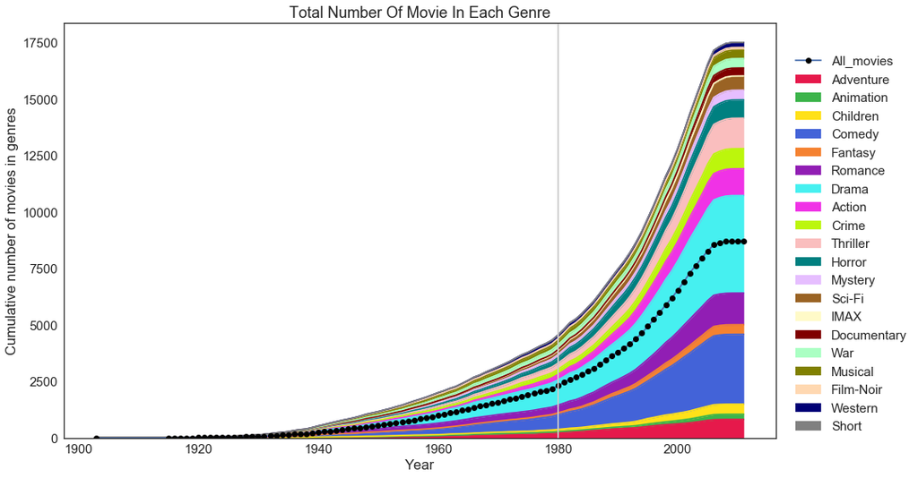

```python
# Create a new dataframe called genres_unique to store all the unique geners in our dataset
genres_unique = pd.DataFrame(new_movies.genre.str.split('|').tolist()).stack().unique()
genres_unique = pd.DataFrame(genres_unique, columns=['genre'])

# Set style, figure of our plot
sns.set_style('white')
plt.figure(figsize=(14,8))

# Create a dataframe to store the accumulative number of movie of each genres in each year
dftmp = new_movies.reset_index()[['id', 'year']].groupby('year')
df = pd.DataFrame({'All_movies' : dftmp.id.nunique().cumsum()})
# Use for loop to iterator each genre in our dataset and count their numbers
for genre in genres_unique.genre:
    dftmp =new_movies[new_movies['genre'].str.find(genre)!=-1].reset_index()[['id', 'year']].groupby('year')
    df[genre]=dftmp.id.nunique().cumsum()
df.fillna(method='ffill', inplace=True)

# Plot histogram for each individual genre
df.loc[:,df.columns!='All_movies'].plot.area(stacked=True, figsize=(15,9),
                                 color = ['#e6194b', '#3cb44b', '#ffe119',
                                '#4363d8', '#f58231', '#911eb4',
                                '#46f0f0', '#f032e6', '#bcf60c',
                                '#fabebe', '#008080', '#e6beff',
                                '#9a6324', '#fffac8', '#800000',
                                '#aaffc3', '#808000', '#ffd8b1',
                                '#000075', '#808080', '#ffffff',
                                '#000000'])

# Plot histogram for all_movies accumulative number
plt.plot(df['All_movies'], marker='o', markerfacecolor='black')
# Set labels of x axes and y axes
plt.xlabel('Year')
plt.ylabel('Cumulative number of movies in genres')
# Set title of our plot
plt.title('Total Number Of Movie In Each Genre')
# Set legend of our plot
plt.legend(loc=(1.02,0), ncol=1)
plt.axvline(1980, color='0.8')
plt.show();
```

#### Findings:

From the picture, we can draw a few conclusions. One point is that the movie industry has bloomed since the 1980s because from the all-movies line, it can be seen that the number of movies increased dramatically. Another point is that there are evident gaps in the growth rate among different genres after the 1980s. The numbers of movies for some genres, such as Drama and Sci-Fi, have accelerated rapidly after the 1980s, while the numbers of movies for other genres, such as Short and Western, have been stagnant.

By doing the research, we found the reason of this finding comes from bigger picture of culture and economic background. 80s is a special time periods in the culture of American history. It is a time period that has distinct ’80s cultural phenomena, from Cold War intrigue to the birth of computing and women’s wrestling respectively. It would be impossible for their central narratives to take place during any other decade. These movement in social and culture feild made the fundation of movie industry and many stories became the topic of movie even until now. The recent blockbuster film "Player One" is a good example, which basically goes through major IPs during 1980s.

Another reason we take into considerasion is ecomonic development. As we all know, the entertainment industry is sensitive to the development of economic. Only when people have extra money, would they spend more on entertainment. After United Stated enter a period of high speed booming of ecomonic in 90s, the movie indudtry also benefit a lot from it. From 1992-1999, the average GDP increased 4% every yaer. The job oppotunities incresed by 170 million, and the unemployment decreased to 4%. These number all demonstrate this fact. We believe economic development plays an important role in this problem.[5]

#### Comparison of two typical genres: 'Sci-Fi' and 'Western'

From the last step, we select two typical movie genres to analyze deeper. One is 'Sci-Fi' and the other is 'Western' because from the last plot, it can be seen that they are representative for bloomed genre and stagnant genre. We compare these two genres by using line chart. The x-axis represents year and the y-axis represents the number of movies.

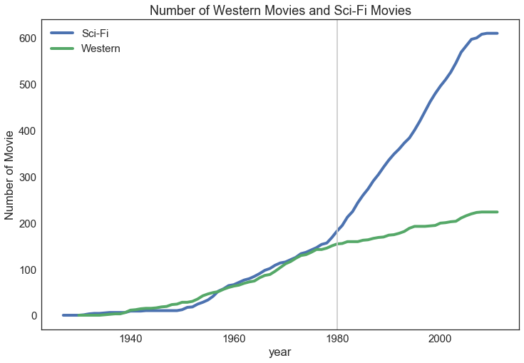

```python
# Plot the number of movies of Sci-Fi and Western movies
sns.set_style('white')
g=df[['Sci-Fi','Western']].plot(figsize=(12,8),linewidth=4)
plt.ylabel('Number of Movie')
plt.title('Number of Western Movies and Sci-Fi Movies')
plt.axvline(1980, color='0.8')
plt.show()
```

#### Findings:

In this picture, it can be seen that before the 1980s, the gap of number of movies between the two movie genre was not large. They developed at a similar speed. However, after the 1980s, the production rates of these two movies genres were completely different. The develop speed of Western movies slowed down and the production of Western movies stagnated, and in contrast, the develop speed of Sci-Fi movies accelerated and the production of Sci-Fi movies increased dramatically.

Based on the domain knowledge of movie industry, the reasons may come from changes in the preferences of audience. Western movie, which is mainly about the story of cowboys and gold rushers, was once a popular type of movie. However, such stories gradually lost their audience due to the development of urbanization and industrialization. The new generation of audience was no longer interested in the story of the Western movie, thus, the production of the Western film has slowed down. In contrast, Sci-Fi movies catered to the interest of new generation of audience: curiosity about advanced technology and pursuit of high quality life. It made Sci-Fi movies become one of the most popular movies since the 1980s.

Same as human, genres also have their life span. The vitality of each genre depends on their audience. Which genre do young generation like? What is the component of a genre's audience? These are the vital questions for the development of genres. The plot above is a good example of genres's life span. The audience of western film in nowadays are mid-age or even old-age people, which means this genres has entered its late stage of life. There will be less money, less attention and less effort to western film.

#### Relationship of audience scores and top 10 Genres

After analyzing the development of movie genres, we next explore the change of the audience score in different genres in history to see how specifically the popularity of movie genres changed. We only choose top 10 genres with the most number of movies because the plot would be too complicated to interpret with all genres in it. We use histogram to visualize our analysis. The x-axis represents year, the y-axis stands for audience score and the color means different movie genres.

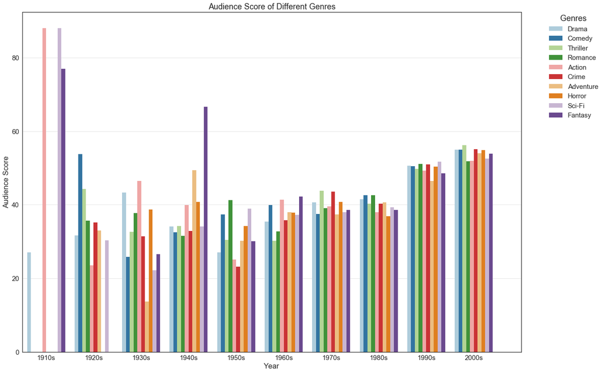

```python
# Set figure of plot
plt.figure(figsize=(20,14))

# Plot top 10 genres of each 10 year
sns.barplot(x='cut', y='rtAudienceScore', hue='genre', palette='Paired',
            hue_order=['Drama','Comedy','Thriller','Romance','Action',
                       'Crime','Adventure','Horror','Sci-Fi','Fantasy'],
            ci=None, data=h);

# Set limitation of Y axes
plt.ylim=(0,100)
plt.grid(b=True, axis='y', which='both', alpha=0.5);

# Set title label legend and xtickers
plt.title('Audience Score of Different Genres')
plt.xlabel('Year')
plt.ylabel('Audience Score')
plt.xticks(range(0,11),['1910s','1920s','1930s','1940s','1950s','1960s','1970s','1980s','1990s','2000s'])
plt.legend(title= 'Genres',loc=2, bbox_to_anchor=(1.05,1.0),borderaxespad = 0.);
```

### 4. The Movie Development in Different Countries

Different countries may have different contributions to the development of movie industry. For example, the development of American movie industry not only affects the American cultural industry, but also affects the global film industry and cultural industry. Thus, we will analyze the development of movie industry in terms of country.

#### Count the number of movies in each country

We first want to count how many movies each country produced from 1910 to 2010. It is because we think the number of movies made in each country could reflect the development degree of movie industry. In general, the more movies the country have, the more mature the movie industry is in that country. We use a donut chart to visualize the number of movies of top 7 countries.

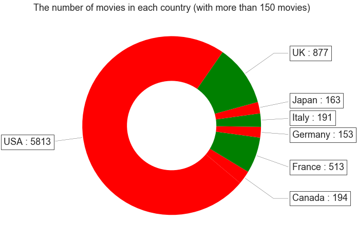

```python
# Count the number of movies in each country
country_rating = pd.DataFrame(new_movies.groupby(by='country').agg({'title': 'count'}))
country_rating.columns = ['count']
top_country = country_rating[country_rating['count'] > 150]
country_rating[country_rating['count'] > 150].sort_values(by = 'count',ascending=False)


# Create donut plot to visualize the number of movies in each country
fig, ax = plt.subplots(figsize=(14, 8), subplot_kw=dict(aspect="equal"))

wedges, texts = ax.pie(top_country['count'], wedgeprops=dict(width=0.5), startangle=-40,colors=['red','green'])

bbox_props = dict(boxstyle="square,pad=0.3", fc="w", ec="k", lw=0.72)
kw = dict(xycoords='data', textcoords='data', arrowprops=dict(arrowstyle="-"),
          bbox=bbox_props, zorder=0, va="center")

# Demonstrate the value of each category instead of percentage as the default value
for i, p in enumerate(wedges):
    ang = (p.theta2 - p.theta1)/2. + p.theta1
    y = np.sin(np.deg2rad(ang))
    x = np.cos(np.deg2rad(ang))
    horizontalalignment = {-1: "right", 1: "left"}[int(np.sign(x))]
    connectionstyle = "angle,angleA=0,angleB={}".format(ang)
    kw["arrowprops"].update({"connectionstyle": connectionstyle})
    ax.annotate(str(top_country.index[i])+' : '+str(top_country['count'][i]), xy=(x, y), xytext=(1.35*np.sign(x), 1.4*y),
                 horizontalalignment=horizontalalignment, **kw)

ax.set_title("The number of movies in each country (with more than 150 movies)")

plt.show()
```

#### Findings:

Based on dataset, the top seven countries with the most number of movies are USA, UK, France, Canada, Italy, Japan and Germany, with 5813 movies, 877 movies, 513 movies, 194 movies, 191 movies, 163 movies and 153 movies respectively. America made much more movies than any other countries. Most of these countries are Europe and America countres and all of these countries are developed countries. It may indicates that the development of movies may be associated with the economical development condition of countries.

After research and analysis, we find that Hollywood impacts the movie industry in USA significantly.

In 1920’s, the movie industry began to flourish, and Hollywood was the rise of an American force. As the birthplace of movie studios, Hollywood were of great importance to America’s public image in the movie industry. The earliest and most affluent film companies were Warner Brothers Pictures, Paramount, RKO, Metro Goldwin Meyer, and 20th Century Fox, each of whom owned their own film production sets and studios. Universal, United, and Columbia Pictures were also considered noteworthy, despite not owning their own theaters, while Disney, Monogram, and Republic were considered third-tier. [6]

However, we also concern that some information are not included in our dataset, such as movies made in india. It is because India's Bollywood is the world's largest movie industry in terms of the number of films produced and tickets sold, but it doesn't appear in our dataset.

#### Changes of the number of movies in top 6 countries

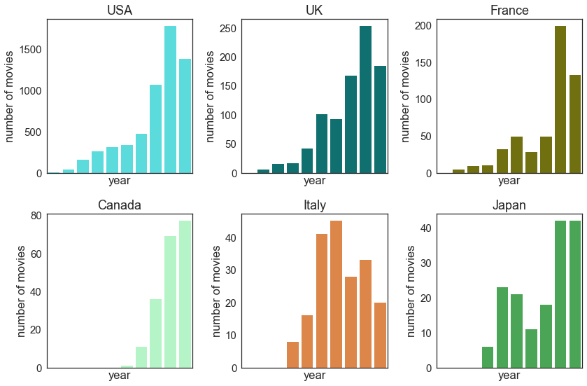

```python
# Create subset of our data set to select country data
country_bin=new_movies[['country','year']]
country_bin['cut']=pd.cut(country_bin['year'],bins)
df1=country_bin.groupby(by=['cut','country']).count().reset_index()
USA = df1[df1['country']=='USA']
UK = df1[df1['country']=='UK']
France = df1[df1['country']=='France']
Canada = df1[df1['country']=='Canada']
Italy = df1[df1['country']=='Italy']
Japan = df1[df1['country']=='Japan']

# Set the style, axes and figure of our plot
sns.set_style('white')
fig, axes = plt.subplots(2, 3)
# Set figure size
fig.set_size_inches(12, 8)
# Set font size
sns.set(font_scale=1.5)

# Plot distribution of 'rtAudienceScore', 'rtTopCriticsScore', 'rtAllCriticsScore' using histgram
d1 = sns.barplot(x='cut',y='year',ax=axes[0,0],color='#46f0f0',data=USA)
d1.title.set_text('USA')
d1.set_xticks([])
d1.set_xlabel('year')
d1.set_ylabel('number of movies')

d2 = sns.barplot(x='cut',y='year',ax=axes[0,1],color='#008080',data=UK)
d2.title.set_text('UK')
d2.set_xticks([])
d2.set_xlabel('year')
d2.set_ylabel('number of movies')

d3 = sns.barplot(x='cut',y='year',ax=axes[0,2],color='#808000',data=France)
d3.title.set_text('France')
d3.set_xticks([])
d3.set_xlabel('year')
d3.set_ylabel('number of movies')

d4 = sns.barplot(x='cut',y='year',ax=axes[1,0],color='#aaffc3',data=Canada)
d4.title.set_text('Canada')
d4.set_xticks([])
d4.set_xlabel('year')
d4.set_ylabel('number of movies')

d5 = sns.barplot(x='cut',y='year',ax=axes[1,1],color='#f58231',data=Italy)
d5.title.set_text('Italy')
d5.set_xticks([])
d5.set_xlabel('year')
d5.set_ylabel('number of movies')

d6 = sns.barplot(x='cut',y='year',ax=axes[1,2],color='#3cb44b',data=Japan)
d6.title.set_text('Japan')
d6.set_xticks([])
d6.set_xlabel('year')
d6.set_ylabel('number of movies')


plt.tight_layout()
```

###### For this vasualization design, we tried many ways to set a proper x-axis for each sub plot to show the years but we failed to do so. Even after we tried using rotation in set_xticks() as we discussed, it still doesn't work. The x-axis are the years from 1910 - 2000 by decades.

#### Findings:

In general, the number of movies in USA, UK and France increased year by year until the 1990s and then decrease. Thus, the development of number of movies in USA, UK and France has similar patterns. Canada started their movie industry in 1960s and the number of movies increased yearly. Italy and Japan started their movie industry in the 1940s and the numbers of movies fluctuated in decades. Overall, movie industry in Canada and Japan are in rising stage while movie industry in USA, UK, France and Italy occurs declining tendency.

### 5. The Change of Movie Cast over Time

We think movie cast (including directors and actors) is another important dimensionality that affect the development of movie industry. Thus, we will analyze the development of movie industry in terms of actors and directors.

#### Change of number of actors over time

We expected to see that the size of movie cast is another important factor in the development of movie industry. Thus, we visualize the changes of number of actors through time period. The x-axis represents the year and the y-axis represents the number of actors.

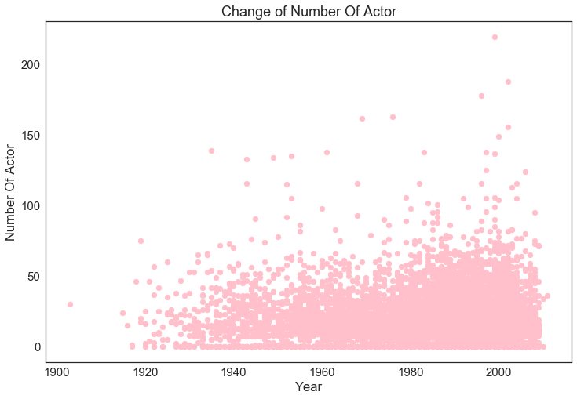

```python
# Scatter plot to show the change of number of actors over in history
plt.figure(figsize=(12,8))
plt.scatter(new_movies['year'],new_movies['numOfActors'],color = 'pink')
plt.title('Change of Number Of Actor')
plt.xlabel('Year')
plt.ylabel('Number Of Actor')
plt.show()
```

#### Findings:

From the plot, the number of actors doesn't change over the history much even though there are slightly more actor in a movie in recent years. This is a good evidence for us to say that movie producers don't need to be too worried about the size of the cast for their new movie because the main stream is to have below 50 actors in a film.

#### Changes of audience score with different number of actors

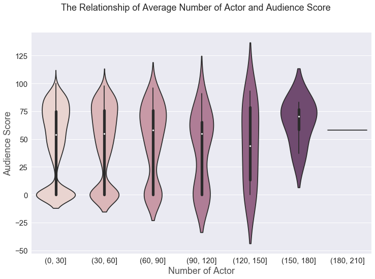

```python
# Create subset of our data set to select number of actor
bins=[0,30,60,90,120,150,180,210]
actor_bin_score=new_movies[['numOfActors','year','rtAudienceScore']]
actor_bin_score['cut']=pd.cut(actor_bin_score['numOfActors'],bins)

# Violin Plots
f, (ax) = plt.subplots(1, 1, figsize=(12, 8))
f.suptitle('The Relationship of Average Number of Actor and Audience Score', fontsize=18)

# Plot designing
sns.set_style('white')
sns.violinplot(x='cut', y='rtAudienceScore', palette=sns.cubehelix_palette(8), data=actor_bin_score,  ax=ax)
ax.set_xlabel("Number of Actor",size = 18,alpha=0.8)
ax.set_ylabel("Audience Score",size = 18,alpha=0.8)

plt.show()
```

#### Findings:

However, from a higher point of view, the influence is not so big that a new movie producer need to pay a lot of attention on this probelm especially when they have limited resources at the begining of career.

There is a very interesting thing in movie industry which is that some successful actors would be director in later of their career. We want to find our that would they also be successful when they are directors.

I will follow the listed bullet points to explore this interesting story.

- First, find the actors who became directors
- Second, I want to know the movie id when these people are actors, if I know the moive id, I know the audience score
- Third, we have the movie id, then we can use this set to find the score distribution.
- Forth, I want to know the movie names when these people are directors and plot the movie score distribution

```python
# Read actors dataset from movie_actors.csv
actors = pd.read_csv(path + 'movie_actors.csv',sep = '\t',
                     encoding='latin1')

# Number of actors in our database
num = actors['actorName'].nunique()
print('Number of actors in our database is :',num)
```

```
Number of actors in our database is : 95241
```

```python
# Find the actors who became directors in their career

# actors_dir is a set a names who are actors and later became directors
actors_dir = set()
for i in actors['actorName']:
    for directors in new_movies['directorName']:
        if i == directors:
            #print(i)
            actors_dir.add(i)
```

```python
# Print how many actors in our data set became directors
print('There are %d actors became directors in dataset' %len(actors_dir))

# Find out the percentage of this career transformation
print('The percentage of this career tansformation is %.2f' %((len(actors_dir)/num)*100),'%')
```

```
There are 1097 actors became directors in dataset
The percentage of this career tansformation is 1.15 %
```

At this moment, We find that out of 95241 actors, 1097 actors became directors later which is 1.15%. There is not a lot of actors became directors in their movie career.

After doing research on this topic, we find that the actor-turned-directors are always extremely successful when they are were actors. Let's take Charles Chaplin as an example. Nobody has been as influential to the world of cinematic comedy as Charles Chaplin. Not only is the The Tramp one of the most iconic characters ever, Chaplin also directed, produced, wrote, composed and acted in most of his films.[7]

Therefore, based on this finding. We do want to know that how do they actually perform in case of audience score before and after they are directors.

```python
# Next, what we want to know is: what is the audience score when these
# people are actors and what is the score when these people are directors

# First, I want to know the movie names when these people are actors,
# if I know the moive name, I would know the audience score of that movie
movies_ID = []
for i in actors_dir:
    for j in range(0,231742):
        if i == actors['actorName'][j]:
            movies_ID.append(actors['movieID'][j])

# With the movie_ID in hand, we can use this list to find the audience
# score information. We also need to drop missing value and exclude 0
# values in the score list to have a clear distribution of the score.
actor_score = new_movies.loc[movies_ID]['rtAudienceScore']
actor_score = actor_score.dropna()
actor_score = actor_score[actor_score > 0]
```

```python
# Second, I want to know the how do they perform when they are
# directors(Find the rtAudienceScore for those movies) when these
# people are directors
rtAudienceScore_dir = []
for i in actors_dir:
    for j in new_movies.index.tolist():
        if i == new_movies['directorName'][j]:
            rtAudienceScore_dir.append(new_movies['rtAudienceScore'][j])
```

```python
# Same as above, we want to exclude 0 scores in the list to have a clearer
# comparasion of distribution of two lists of scores
new_rtAudienceScore_dir = []
for i in range(len(rtAudienceScore_dir)):
    if rtAudienceScore_dir[i] > 0:
        new_rtAudienceScore_dir.append(rtAudienceScore_dir[i])
```

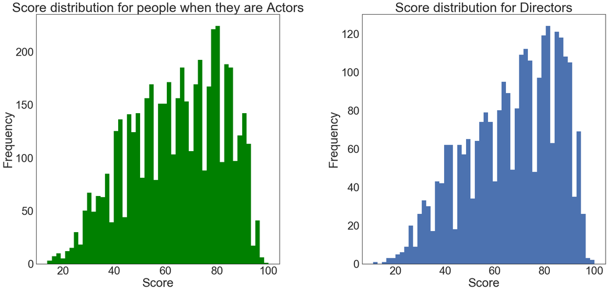

```python
# Plot two distribution of scores for actors and actors-turned-directors respectively

# Plot for actors
plt.figure(figsize=(24,12))
plt.subplot(1,2,1)
actor_score.plot(kind='hist', bins = 50, color = 'g')
plt.xlabel('Score')
plt.ylabel('Frequency')
plt.title('Score distribution for people when they are Actors')


# Plot directors score
plt.subplot(1,2,2)
plt.hist(new_rtAudienceScore_dir, bins = 50)
plt.xlabel('Score')
plt.ylabel('Frequency')
plt.title('Score distribution for Directors')

plt.tight_layout()
```

#### Findings:

It's very interesting to find that the distributions of audience score for actor-turned-directors before and after transformation are quite similiar. Even though this is counterintuitive because we thought that actors-turned-directors would not perform as well as they do as actors. After some research about this, we do find that it's very natualy for some excellent actors to filming by themselves. Directoring a movie a about storytelling and after years of accumulation about different stories, they would have the ability to produce high quality stories and movies.[7]

In addition, as we can see from the plot that there are many gaps between the plot. This is probably because movie viewers are less likely to rating movies at every 5 points level, which means that when they are rating, they are more willing to give a movie score ends 1-4 instead of 5.

## Conclusion

#### Insights on business values from conclusions:

In the recent several decades, the number of movies increased dramatically. Therefore, the movie industry has a bright future and it's worthy for many more new movie producers to learn about this industry. According to our analysis, paying attention to different evaluation methods in movie industry is very important if film producer newbies want to get acknowledged or to be successful in their career. It's necessary for them to know that critics opinions are more proper for long-term assesment for a movie, contrast to general audience's reviews that are more focused on the short term satisfaction. Secondly, a new movie producer should feel confident because of the movie industry are getting better which we can see from the increase of the movie score in history. Thirdly, genres are definitly the foundation of a movie's style and performance. New movie producers do need to follow the historical trend and produce movies that people like in terms of genres. Fourthly, it's not necessary to be worried that a movie need as many as actors as they could have because there is no strong relationship between high quality and huge amount of actors. Finally, learn from actor-turned-directors because they really have a extrodinary performance whenever they are actors or directors. They also might give a newbie movie producer inspiration to write a good stories or opportunity to meet with good actors who are not popular yet.

The result of this analysis is a good resource for newbie movie producer to get familiar with the movie industry. They can have a first glance on the development of the industry and what factors they need to pay attention to for earning a satisfactory result and being successful in their career.

### Reference

- [1]. https://historycooperative.org/the-history-of-the-hollywood-movie-industry/
- [2]. https://filmschoolrejects.com/pop-culture-obsessed-with-1980s/
- [3]. https://www.history.com/news/how-tv-killed-hollywoods-golden-age
- [4]. https://stephenfollows.com/genre-trends-global-film-production/
- [5]. https://medium.com/singulardtv/30-stats-that-reveal-the-economics-of-the-entertainment-industry-18e9a5db493b
- [6]. https://historycooperative.org/the-history-of-the-hollywood-movie-industry/
- [7]. http://www.dazeddigital.com/artsandculture/article/24394/1/why-do-actors-become-directors